# Coursework Report

*N* removed NAs: 2

*N* removed typo: 1

*N* removed <18: 24

*N* total clean: 123

| Group | *N* | *M*<sub>age</sub> | *M*<sub>rating</sub> |
| --- | --- | --- | --- |
| Control | 62 | 21.03 | 7.07 |
| Experim | 61 | 21.13 | 6.03 |

**Main analysis results**

*t*(121) = 6.59, *p* < .001

[interactive chart not shown]

[figure not shown]

[interactive chart not shown]

# Coursework Report

Analysing Data, Spring 2020

# Methods

## Participants

Initially, 150 volunteers participated in the experiment. Data from 24 participants got removed due to unethical reported ages, while data from one participant got excluded due to an unlikely value of age. Only 123 (*M*<sub>AGE</sub> = 21.08, *SD*<sub>AGE</sub> = 2.05, range = 18 - 27) participants were included in our investigation. Table 1 shows the age and number of participants in the two experimental conditions.

Table 1 *Summary of Participants Demographics by Experimental Condition*

| Condition | Count | *M*<sub>AGE</sub> | *SD*<sub>AGE</sub> |
| --- | --- | --- | --- |
| control | 62 | 21.03 | 2.19 |
| experimental | 61 | 21.13 | 1.93 |

## Design

In our experiment, we examined how women’s perceptions of a man’s attractiveness was affected by the colors red and white. Participants viewed a black-and-white picture of a man on a red(n=61), or white(n=62) background for 5 seconds. They reported their perceptions on the attractiveness of the man. Attractiveness was assesed on three-face value items: “How attractive do you think this person is?”, “How pleasant is this person to look at?” and “If I were to meet the person in this picture face to face, I would think he is attractive. Items were rated on a 9-point value scale. The higher the scale value was, the more attractive the man was perceived to be. Scores were averaged to create a composite score. We want to see if viewing a different colour frame around an image of a moderately attractive man influences the mean ratings of his attractiveness. To examine this, we will perform an independent-samples T test.

# Results

We investigated whether participants would give different ratings of a man’s attractiveness depending on the color condition. Firstly, ratings on attractiveness from each condition were averaged to create a composite score. Surprinsingly, participants in the control, white condition rated the target man as more attractive (*M* = 7.07) compared to the ones in the experimental, red condition (*M* = 6.03). An independent-measures *T*-test examining the influence of color condition on perceived attractivenes was performed. The analysis indicated that the difference in mean attractiveness ratings of the control vs experimental groups was significant (*M*<sub>diff</sub> = 1.04, 95% CI [0.73, 1.36], *t* (121) = 6.59, *p* = < .001)). We know that if the null hypothesis is true, then the difference in the means should be 0, which is not our case. The difference in the attraction means is compared to the standard devation of the difference in means to produce our *T* test. The probability *p* of finding a value of *T* as big as 6.58 is quite low, *p* < .001. Therefore, it is unlikely that our samples come from the same populations, which means that whether a participant gives a different rating of a man’s attractiveness, is influenced by the color condition.

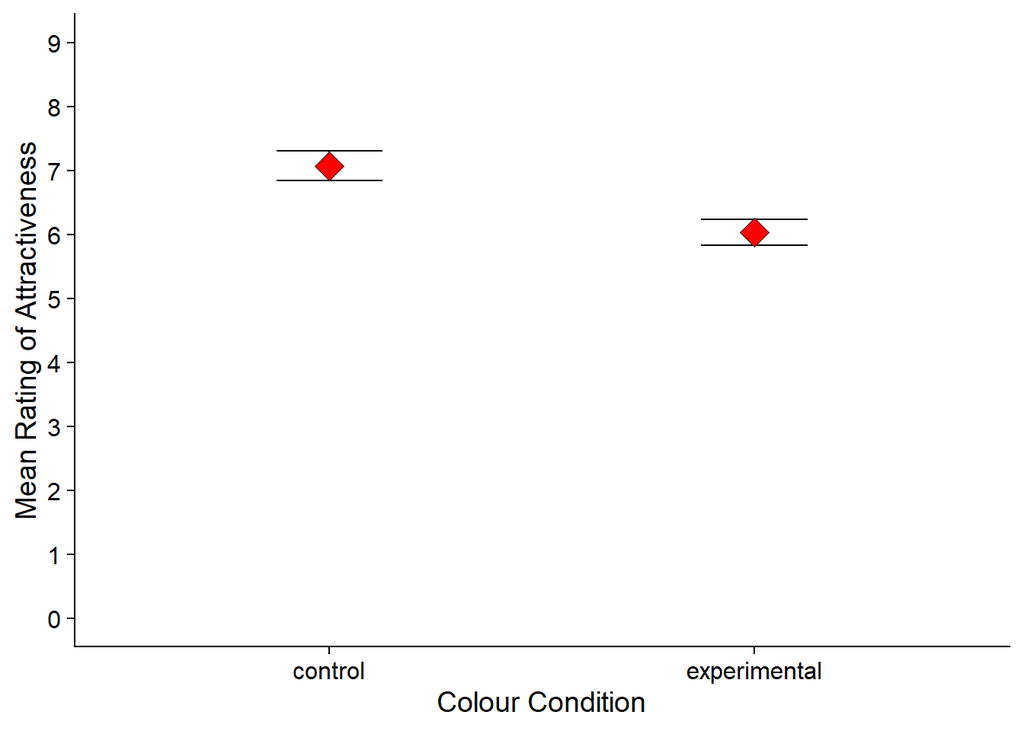

```
##
##  Two Sample t-test
##
## data:  attract by GROUP
## t = 6.5869, df = 121, p-value = 0.000000001225
## alternative hypothesis: true difference in means is not equal to 0
## 95 percent confidence interval:
##  0.7292147 1.3559254
## sample estimates:
##      mean in group control mean in group experimental
##                   7.069892                   6.027322
```

# Discussion

Our study investigated the influence of color condition on perceived attractiveness, that is, whether participants would give different ratings of a target man’s attractiveness, based on the background color of the presented pictures. By performing an independent *T*-test, a significant color effect was uncovered. Surprisingly, participants in the control, white condition rated the man as more attractive than the ones in the experimental, red condition. These results signify that color white has a significant influence on the perceived attractiveness of men. This was not the result pattern we expected. The study is a replication attempt of (Elliot et al., 2010), meaning that the same type of design, variables and stimuli were used, however, our participants samples being different. The same picture was used, same background colors and the same amount of time for which it was presented. While in (Elliot et al., 2010) original study, participants in the red condition rated the man as more attractive than the ones in the white condition, our study showed an opposite result pattern. This might be caused by the difference in the population samples, as our study used a way larger sample size (total N= 123) then Elliot’s study (total N=21). More, we do not know the ethnicity of our participants, while (Elliot et al., 2010) states that it tested people from 4 different countries. This is a limitation of our study. As we cannot directly comment on the findings of Eliot’s study because of the big difference in our participants sample, which is a cause for our opposite pattern of results, we can, more suitably, account this effect for the “Color in Context Theory”, developed by (Elliot & Maier, 2012), thus, offering greater insight into how this might positively influence the development of the field. As we said, an alternative explanation for our results could be attributed to the “Color in Context Theory”, which states that colors can have different meanings in different situations and can generate different behaviors. These meanings can be derived from cultural learning. We know that (Elliot & Maier, 2012) states that color red is commonly associated with passion, sexuality, and high status, the last one being a mediator for the influence of color red on perceived attractiveness in the (Elliot et al., 2010) study. However, we are interested in the social and cultural associations with the color white, which is the color that had significant effects in our results. White is a powerful symbol in some societies showing high virtues, innocence, purity (Hesslinger et al., 2015). Now, we don’t know the ethnicity of our participants, therefore, the cultures from which they come from, so we suspect that an alternative explanation for our opposite pattern of results would be based on the Color in Context Theory. Another study (Peperkoorn et al., 2016) wanted to verify the ecological validity of Eliot’s study, more specific, to examine the red effect. One of their experiments was a close replication of Eliot’s first experiment, the same as ours, having the same design and variables. Again, the sample of participants was larger (N=89), which might have accounted for the different pattern of results: this time, color red was found to not have any significant effect on perceived attractiveness. These 3 studies, including our own, all have different pattern results, for which an explainable cause is the variability in participants samples. Our study and (Peperkoorn et al., 2016) prove that color red does not have such a strong influence on perceived attractiveness, as it was thought before. More, our study, accounts for the white effect, which was found to be significant, proving that different colors can have as strong influence on the specific variable. For future research, we suggest the use of “Color in Context Theory” as an explanation, more specific the social and cultural association with colors, and this association affects perceived attractiveness. In conclusion, we found a significant color effect on our dependent variable, which is perceived attractiveness. More specific, our pattern of results was different from other studies in the research area, showing the influence and significance of color white on perceived attractiveness. We believe this is partly caused by the cultural and social associations which are described by the “Color in Context Theory”(Elliot & Maier, 2012). We suggest further research based on this assumption.

# References

Elliot, A. J., & Maier, M. A. (2012). Chapter two—Color-in-Context Theory. In P. Devine & A. Plant (Eds.), Advances in Experimental Social Psychology (Vol. 45, pp. 61–125). Academic Press. https://doi.org/10.1016/B978-0-12-394286-9.00002-0

Elliot, A. J., Niesta Kayser, D., Greitemeyer, T., Lichtenfeld, S., Gramzow, R. H., Maier, M. A., & Liu, H. (2010). Red, rank, and romance in women viewing men. Journal of Experimental Psychology: General, 139(3), 399–417. https://doi.org/10.1037/a0019689

Hesslinger, V. M., Goldbach, L., & Carbon, C.-C. (2015). Men in red: A reexamination of the red-attractiveness effect. Psychonomic Bulletin & Review, 22(4), 1142–1148. https://doi.org/10.3758/s13423-015-0866-8

Peperkoorn, L. S., Roberts, S. C., & Pollet, T. V. (2016). Revisiting the Red Effect on Attractiveness and Sexual Receptivity: No Effect of the Color Red on Human Mate Preferences. Evolutionary Psychology, 14(4), 1474704916673841. https://doi.org/10.1177/1474704916673841